# Homework 11 - Machine learning essentials

Leo Li (PID: 730031954)

04/20/2021

# Use of `caret` with various methods

Run three machine learning models over the following training dataset with features `x` and labels `y`. You can use default tuning, e.g. bootstrap based resampling for tuning, as set by `trainControl`.

- SVM with radial kernel `"svmRadial"`
- Random forest `"rf"`
- Gradient boosting machine `"gbm"` (use `verbose=FALSE`)

Record the time to train, and the best Kappa value for each method over the tuning grid (`rf` does not use tuning parameters via `train` for this dataset). Which method obtains the best Kappa?

Finally, make a `pointrange` plot (see `geom_pointrange`), with the optimal Kappa and the SD for the optimal Kappa. Is there a clear winner, or all the methods mostly overlapping?

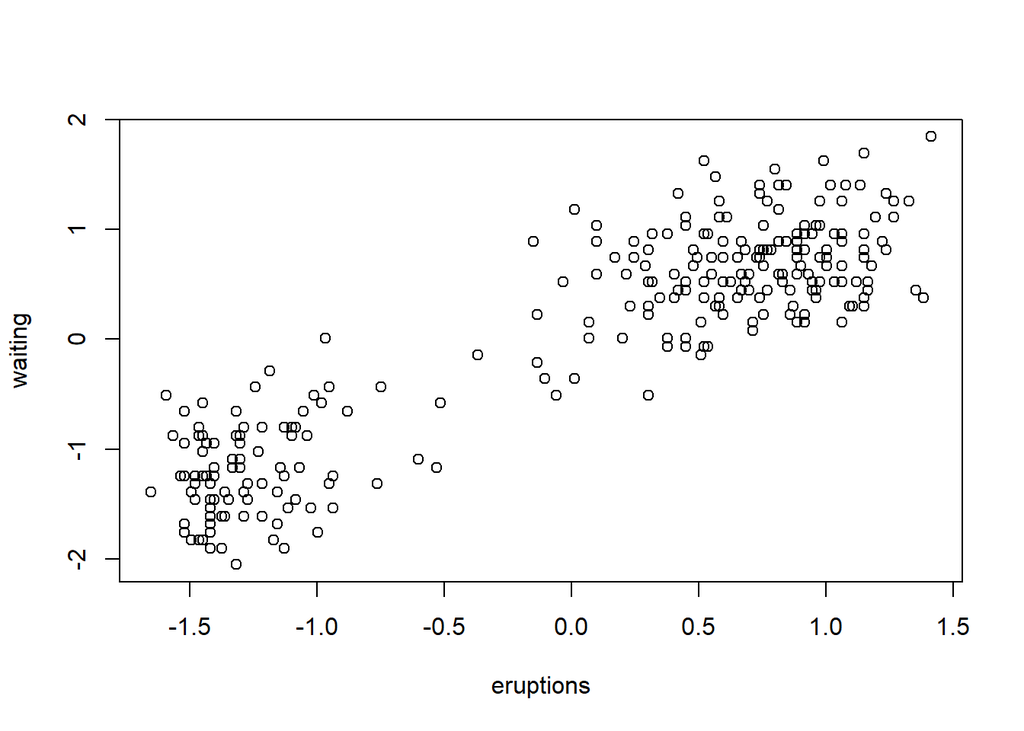

```r
data(faithful)
n <- nrow(faithful)
faithful <- data.frame(lapply(faithful, scale))
plot(faithful)
```

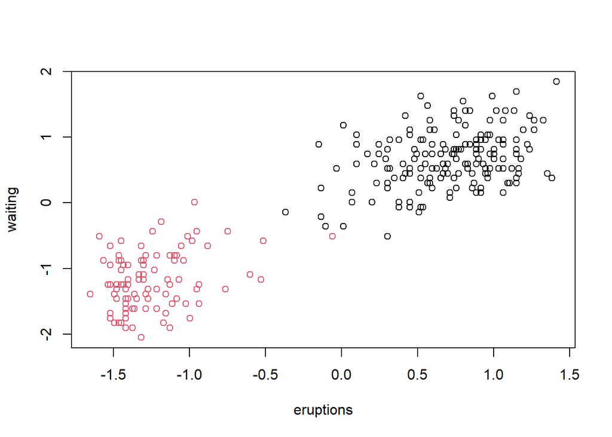

```r
faithful$cl <- factor(kmeans(faithful, centers=2)$cluster)
plot(faithful[,1:2], col=faithful$cl)
```

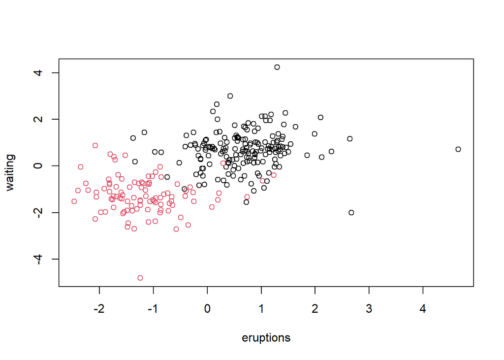

```r
# make it more challenging
set.seed(1)
faithful[,1] <- faithful[,1] + rt(n,df=5)/2
faithful[,2] <- faithful[,2] + rt(n,df=5)/2
plot(faithful[,1:2], col=faithful$cl)
```

```r
x <- faithful[,1:2]
y <- faithful[,3]
```

First, we run the three machine learning methods, and output the training time and optimal Kappa.

```r
# SVM with radial kernel
start1 = Sys.time()
fit1 <- train(x, y, method="svmRadial")
end1 = Sys.time()
out1 <- fit1$results[rownames(fit1$bestTune),]
kappa1 <- out1$Kappa
kappasd1 <- out1$KappaSD

# Random forest
start2 = Sys.time()
fit2 <- train(x, y, method="rf")
end2 = Sys.time()
out2 <- fit2$results[rownames(fit2$bestTune),]
kappa2 <- out2$Kappa
kappasd2 <- out2$KappaSD

# Gradient boosting machine
start3 = Sys.time()
fit3 <- train(x, y, method="gbm", verbose=FALSE)
end3 = Sys.time()
out3 <- fit3$results[rownames(fit3$bestTune),]
kappa3 <- out3$Kappa
kappasd3 <- out3$KappaSD

df=data.frame(Method=c("svmRadial","rf","gbm"), Kappa=c(kappa1,kappa2,kappa3), KappaSD=c(kappasd1, kappasd2, kappasd3), Time=c(end1-start1,end2-start2,end3-start3))
df
```

```
##      Method     Kappa    KappaSD          Time
## 1 svmRadial 0.9085400 0.03477917 2.411867 secs
## 2        rf 0.8756553 0.04302251 1.868191 secs
## 3       gbm 0.8899242 0.04733382 1.859964 secs
```

Based on the results, we can see that SVM with radial kernel obtains the best Kappa.

Now, we make a `pointrange` plot, with the optimal Kappa and the SD for the optimal Kappa.

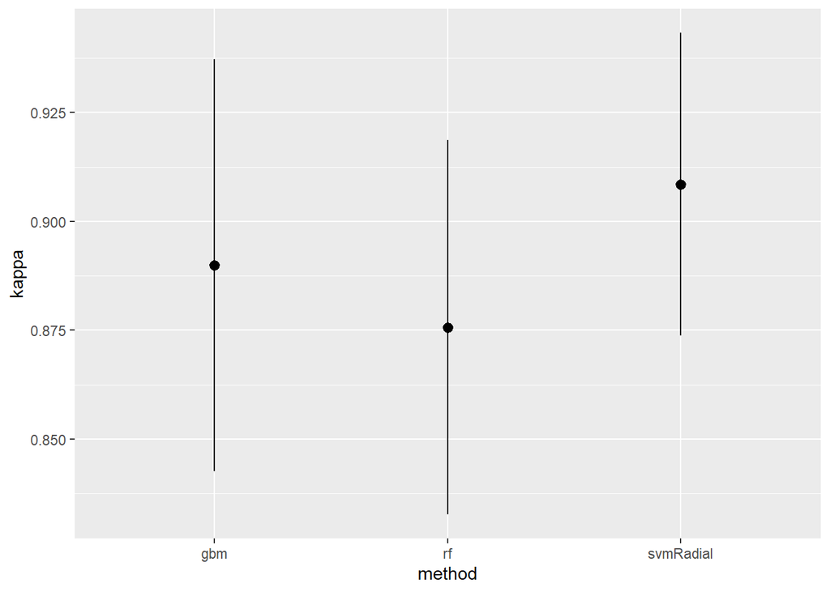

```r
r = 1
d=data.frame(method=c("svmRadial","rf","gbm"), kappa=c(kappa1,kappa2,kappa3), lower=c(kappa1-r*kappasd1,kappa2-r*kappasd2,kappa3-r*kappasd3), upper=c(kappa1+r*kappasd1,kappa2+r*kappasd2,kappa3+r*kappasd3))
ggplot() + geom_pointrange(data=d, mapping=aes(x=method, y=kappa, ymin=upper, ymax=lower))
```

From the `pointrange` plot, we can see that there is no clear winner among the methods that we have considered, since a large proportion of the `pointrange` plots for the three methods are overlapping.